# Nigeria Micro-nutrient Deficiencies

# Nigeria micro-nutrient deficiency data sources

Table 1: Micro-nutrient deficiency data sources for Nigeria

Source

Spatial Resolution

Most recent data

Deficiencies

Population

National Food Consumption and Micro nutrient Survey (NFCMS) 2021

Geopolitical Zone

2021

- serum retinol (vitamin A)
- women 15–49
- children 6–59 months

NFCMS

”

”

- serum ferritin / haemoglobin
- women 15–49
- children 6–59 months

NFCMS

”

”

- serum zinc
- women 15–49
- children 6–59 months

Nigeria Demographic and Health Survey (NDHS) 2023-24

State

2023-24

- haemoglobin /anaemia
- children 6–59 months
- women 15–49

NDHS 2023-24

State

2023-24

- Stunting
- children 6–59 months

Modelled Data from 2018/19 Food consumption (Ishida et al., 2026 (submitted))

LGA

2018-19

Apparent micro-nutrient intake estimated for:

- folate
- vitamin B12
- iron
- household

IHME - Global Burden of Disease (GBD)

State

2023

Age standardised DALYs: - Vitamin A deficiency - Dietary iron deficiency

- population

(Federal Government of Nigeria (FGoN) and International Institute of Tropical Agriculture (IITA) 2024) (Federal Ministry of Health and Social Welfare of Nigeria (FMoHSW) et al. 2025) (Ishida et al. 2026 (submitted))

The data at state level need to be joined to the Nigeria States spatial dataset, and the data at zone level need to be joined to the geopolitical zones.

The stages are:

1. Load the States dataset
2. Load the geopolitical zone
3. Load each health database
4. For each indicator in the database join to the state or zone spatial dataset and plot

# Load the States

The source of the states data is from OSGOF-Ehealth-UNCS. These have previously been cleaned to remove sliver polygons and gaps, and were saved as a topojson format.

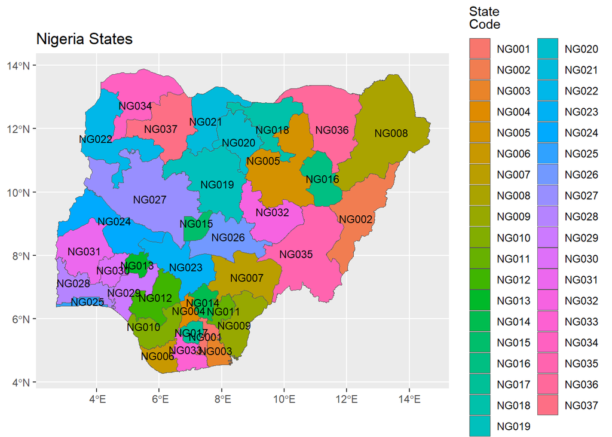

```r
vect_state_geo <- vect("D:/DatosProyecto/SpatialData/Africa/Pais/Nigeria/NGA Admin 2019-2025 OSGOF-Ehealth-UNCS/nga_admin1_topo.topojson")

crs(vect_state_geo) <- "epsg:4326"

vect_state_geo$adm1_pcode <- as.factor(vect_state_geo$adm1_pcode)

# levels(vect_state_geo$adm1_pcode) # Check levels

ggplot(vect_state_geo)+
  geom_spatvector(aes(fill = adm1_pcode)) +
  geom_spatvector_text(aes(label = adm1_pcode), size = 3) +
  labs(
    title = "Nigeria States",
    fill = "State<br>Code") +
  theme(
    plot.title = element_markdown(),
    legend.title = element_markdown(),
    axis.title = element_blank()
  )
```

```r
df_state <- as.data.frame(vect_state_geo)
```

# Load the geopolitical zones

The geopolitical zones are a combination of states with similar ethnic groups, and/or common political history.

There are six zones:

| Zone name | States |
| --- | --- |
| North Central | Benue, Kogi, Kwara, Nasarawa, Niger, and Plateau States, and Federal Capital Territory |
| North East | Adamawa, Bauchi, Borno, Gombe, Taraba, and Yobe |
| North West | Jigawa, Kaduna, Kano, Katsina, Kebbi, Sokoto, and Zamfara |
| South East | Abia, Anambra, Ebonyi, Enugu, and Imo |
| South South | Akwa Ibom, Bayelsa, Cross River, Delta, Edo, and Rivers |
| South West | Ekiti, Lagos, Ogun, Ondo, Osun, and Oyo |

The zones are created by joining the states.

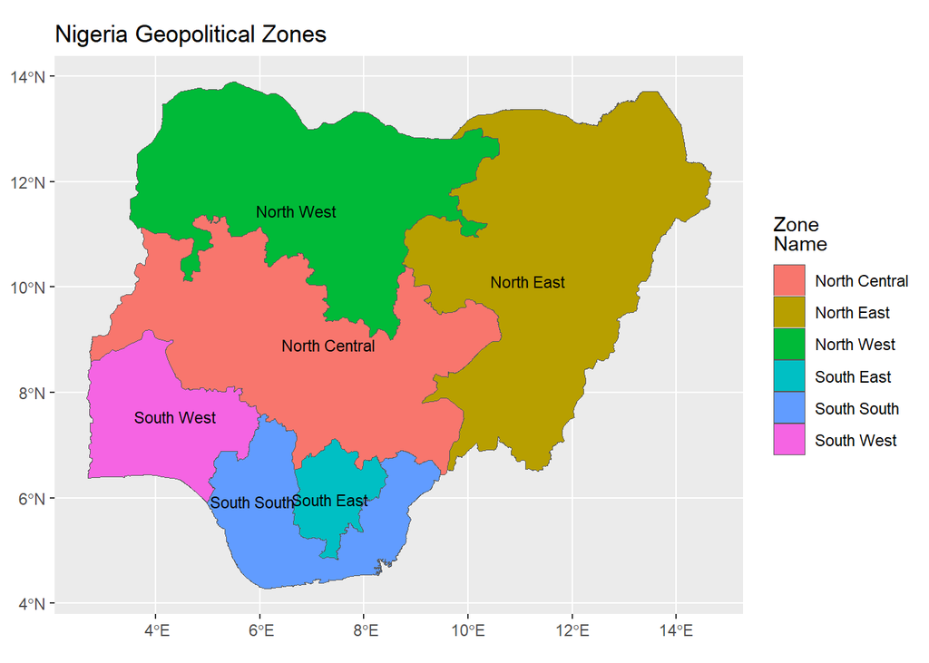

```r
adm1_pcode <- c("NG001", "NG002", "NG003", "NG004", "NG005", "NG006",
"NG007", "NG008", "NG009", "NG010", "NG011", "NG012", "NG013", "NG014",
"NG015", "NG016", "NG017", "NG018", "NG019", "NG020", "NG021", "NG022",
"NG023", "NG024", "NG025", "NG026", "NG027", "NG028", "NG029", "NG030",
"NG031", "NG032", "NG033", "NG034", "NG035", "NG036", "NG037")

geopolitical_zone <- c("South East", "North East", "South South",
"South East", "North East", "South South", "North Central", "North East",
"South South", "South South", "South East", "South South", "South West",
"South East", "North Central", "North East", "South East", "North West",
"North West", "North West", "North West", "North West", "North Central",
"North Central", "South West", "North Central", "North Central",
"South West", "South West", "South West", "South West", "North Central",
"South South", "North West", "North East", "North East", "North West")

df_gpz <- tibble(adm1_pcode, geopolitical_zone)

vect_gpz_geo <- dplyr::left_join(vect_state_geo, df_gpz, by =
c("adm1_pcode")) |> aggregate(by = "geopolitical_zone")

ggplot(vect_gpz_geo)+
  geom_spatvector(aes(fill = geopolitical_zone)) +
  geom_spatvector_text(aes(label = geopolitical_zone), size = 3) +
  labs(
    title = "Nigeria Geopolitical Zones",
    fill = "Zone<br>Name") +
  theme(
    plot.title = element_markdown(),
    legend.title = element_markdown(),
    axis.title = element_blank()
  )
```

# NFCMS 2021

## Load the database

The NFCMS data are loaded and there are data available for the following zones:

```r
df_NFCMS <- read.csv("E:/repos/Nigeria_Biofortification_Atlas/tab_data/NFCMS_deficiencies.csv")

df_NFCMS$geopolitical_zone <- as.factor(df_NFCMS$geopolitical_zone)

cat(paste(levels(df_NFCMS$geopolitical_zone), "; ")) # Check levels
```

North Central ; North East ; North West ; South East ; South South ; South West ;

## Join the NFCMS database to the zone dataset

The NFCMS dataset does not contain codes for the zones - only names. Therefore we need to join the two data frames using the name of the zone - and checking that all zones have data.

```r
vect_gpz_geo_NFCMS <- dplyr::left_join(vect_gpz_geo, df_NFCMS, by = c("geopolitical_zone"))
vect_gpz_geo_NFCMS |> as.data.frame() |>
  DT::datatable(
    rownames = F,
    filter = "bottom",
    selection = list(mode = "none"),
    editable = FALSE,
    options = list(
      digits = 0,
      scrollX = TRUE,
      scrollCollapse = TRUE,
      autoWidth = TRUE,
      fixedColumns = list(leftColumns = 2),
      lengthMenu = c(15, 40),
      pageLength = 15
    ))
```

| geopolitical_zone | mean_area_sqkm | mean_center_lat | mean_center_lon | id | valid_on | valid_to | adm0_pcode | adm0_name3 | adm1_ref_name | adm0_name2 | adm0_name | adm1_pcode | adm0_name1 | lang1 | lang3 | adm1_name3 | adm1_name2 | version | lang | adm1_name1 | adm1_name | lang2 | agg_n | CH_def_iron_pc_235 | CH_def_anaemia_pc_235 | CH_def_vit_A_pc_236 | CH_def_vit_B12_pc_237 | CH_def_zinc_pc_238 | WRA_def_iron_pc_245 | … |
| --- | --- | --- | --- | --- | --- | --- | --- | --- | --- | --- | --- | --- | --- | --- | --- | --- | --- | --- | --- | --- | --- | --- | --- | --- | --- | --- | --- | --- | --- | --- |
| North Central | 32374.02856471428 | 8.683830957142858 | 7.281445614285714 |  | 2019-04-17T05:00:00Z |  | NG |  |  |  | Nigeria |  |  |  |  |  |  | v01 | en |  |  |  | 7 | 20.7 | 8 | 15.5 | 1.1 | 23.4 | 9.1 | … |
| North East | 46551.80045726667 | 10.41556971666667 | 11.36336905 |  | 2019-04-17T05:00:00Z |  | NG |  |  |  | Nigeria |  |  |  |  |  |  | v01 | en |  |  |  | 6 | 27.9 | 7.5 | 31.7 | 4.1 | 31.2 | 15.5 | … |
| North West | 30559.98868224286 | 11.78441014285714 | 6.968847014285714 |  | 2019-04-17T05:00:00Z |  | NG |  |  |  | Nigeria |  |  |  |  |  |  | v01 | en |  |  |  | 7 | 25.5 | 13 | 50.6 | 4.5 | 56.5 | 9.1 | … |
| South East | 5742.88735864 | 6.00114194 | 7.38378392 |  | 2019-04-17T05:00:00Z |  | NG |  |  |  | Nigeria |  |  |  |  |  |  | v01 | en |  |  |  | 5 | 11.5 | 3.8 | 6.1 | 1.1 | 11.8 | 10.4 | … |
| South South | 13999.63981785 | 5.508994833333333 | 6.726541516666667 |  | 2019-04-17T05:00:00Z |  | NG |  |  |  | Nigeria |  |  |  |  |  |  | v01 | en |  |  |  | 6 | 9.4 | 4 | 18.8 | 0.2 | 22.4 | 12.2 | … |
| South West | 12895.26095053333 | 7.309125083333333 | 4.21263045 |  | 2019-04-17T05:00:00Z |  | NG |  |  |  | Nigeria |  |  |  |  |  |  | v01 | en |  |  |  | 6 | 10.8 | 4.4 | 18.5 | 0 | 22.7 | 5.2 | … |

# NDHS 2023-24

## Load the databases

The NDHS state data are loaded and there are data available for the following states:

```r
df_NDHS_state <- read.csv("E:/repos/Nigeria_Biofortification_Atlas/tab_data/NDHS_state_deficiencies.csv")
# change name to match states dataset
df_NDHS_state['State'][df_NDHS_state['State'] == "FCT-Abuja"] <- "Federal Capital Territory"

df_NDHS_state$State <- as.factor(df_NDHS_state$State)

cat(paste(levels(df_NDHS_state$State), "; ")) # Check levels
```

Abia ; Adamawa ; Akwa Ibom ; Anambra ; Bauchi ; Bayelsa ; Benue ; Borno ; Cross River ; Delta ; Ebonyi ; Edo ; Ekiti ; Enugu ; Federal Capital Territory ; Gombe ; Imo ; Jigawa ; Kaduna ; Kano ; Katsina ; Kebbi ; Kogi ; Kwara ; Lagos ; Nasarawa ; Niger ; Ogun ; Ondo ; Osun ; Oyo ; Plateau ; Rivers ; Sokoto ; Taraba ; Yobe ; Zamfara ;

```r
df_NDHS_stunting_state <- read.csv("E:/repos/Nigeria_Biofortification_Atlas/tab_data/Nigeria_NDHS2024_stunting_GBD_join.csv")


df_NDHS_stunting_state$state <- as.factor(df_NDHS_stunting_state$state)

cat(paste(levels(df_NDHS_stunting_state$state), "; ")) # Check levels
```

Abia ; Adamawa ; Akwa Ibom ; Anambra ; Bauchi ; Bayelsa ; Benue ; Borno ; Cross River ; Delta ; Ebonyi ; Edo ; Ekiti ; Enugu ; Federal Capital Territory ; Gombe ; Imo ; Jigawa ; Kaduna ; Kano ; Katsina ; Kebbi ; Kogi ; Kwara ; Lagos ; Nasarawa ; Niger ; Ogun ; Ondo ; Osun ; Oyo ; Plateau ; Rivers ; Sokoto ; Taraba ; Yobe ; Zamfara ;

The NDHS zone data are loaded and there are data available for the following zones:

```r
df_NDHS_zone <- read.csv("E:/repos/Nigeria_Biofortification_Atlas/tab_data/NDHS_zone_deficiencies.csv")

df_NDHS_zone$Zone <- as.factor(df_NDHS_zone$Zone)

cat(paste(levels(df_NDHS_zone$Zone), "; ")) # Check levels
```

North Central ; North East ; North West ; South East ; South South ; South West ;

## Join the NDHS database to the state dataset

The NDHS dataset does not contain codes for the states - only names. Therefore we need to join the two data frames using the name of the state - and checking that all states have data.

```r
vect_state_geo_NDHS <- dplyr::left_join(vect_state_geo, df_NDHS_state, by = c("adm1_ref_name"  = "State"))
vect_state_geo_NDHS |> as.data.frame() |>
  DT::datatable(
    rownames = F,
    filter = "bottom",
    selection = list(mode = "none"),
    editable = FALSE,
    options = list(
      digits = 0,
      scrollX = TRUE,
      scrollCollapse = TRUE,
      autoWidth = TRUE,
      fixedColumns = list(leftColumns = 2),
      lengthMenu = c(15, 40),
      pageLength = 15
    ))
```

| id | area_sqkm | valid_on | valid_to | adm0_pcode | adm0_name3 | adm1_ref_name | adm0_name2 | adm0_name | adm1_pcode | adm0_name1 | lang1 | lang3 | adm1_name3 | adm1_name2 | version | lang | adm1_name1 | adm1_name | lang2 | center_lat | center_lon | CH_anaemia_any | CH_anaemia_mild | CH_anaemia_mod | CH_anaemia_sev | WRA_anaemia_any | WRA_anaemia_mild | WRA_anaemia_mod | WRA_anaemia_sev |
| --- | --- | --- | --- | --- | --- | --- | --- | --- | --- | --- | --- | --- | --- | --- | --- | --- | --- | --- | --- | --- | --- | --- | --- | --- | --- | --- | --- | --- | --- |
|  | 4859.5031378 | 2019-04-17T05:00:00Z |  | NG |  | Abia |  | Nigeria | NG001 |  |  |  |  |  | v01 | en |  | Abia |  | 5.4318197 | 7.4883421 | 64.1 | 38.4 | 25.4 | 0.3 | 66.3 | 28.7 | 36.5 | 1.2 |
|  | 37821.6738411 | 2019-04-17T05:00:00Z |  | NG |  | Adamawa |  | Nigeria | NG002 |  |  |  |  |  | v01 | en |  | Adamawa |  | 9.1626472 | 12.2915621 | 59 | 25.1 | 29.3 | 4.6 | 50 | 22.4 | 26.3 | 1.3 |
|  | 6739.3559919 | 2019-04-17T05:00:00Z |  | NG |  | Akwa Ibom |  | Nigeria | NG003 |  |  |  |  |  | v01 | en |  | Akwa Ibom |  | 4.99047 | 7.7955686 | 74.5 | 28.3 | 45.6 | 0.7 | 54.8 | 24.8 | 28.9 | 1.1 |
|  | 4805.5194821 | 2019-04-17T05:00:00Z |  | NG |  | Anambra |  | Nigeria | NG004 |  |  |  |  |  | v01 | en |  | Anambra |  | 6.2485292 | 6.9378734 | 52.9 | 30.3 | 21.9 | 0.6 | 54.9 | 32.5 | 22.4 | 0.1 |
|  | 48516.7133317 | 2019-04-17T05:00:00Z |  | NG |  | Bauchi |  | Nigeria | NG005 |  |  |  |  |  | v01 | en |  | Bauchi |  | 10.9978941 | 9.3258168 | 65.3 | 25.1 | 37.3 | 2.9 | 54.4 | 27.1 | 24 | 3.3 |
|  | 9529.0165288 | 2019-04-17T05:00:00Z |  | NG |  | Bayelsa |  | Nigeria | NG006 |  |  |  |  |  | v01 | en |  | Bayelsa |  | 4.8268244 | 5.951137 | 50.1 | 30.7 | 18.6 | 0.8 | 47.7 | 27.8 | 19.9 | 0 |
|  | 31483.3370793 | 2019-04-17T05:00:00Z |  | NG |  | Benue |  | Nigeria | NG007 |  |  |  |  |  | v01 | en |  | Benue |  | 7.3009378 | 8.8123949 | 51 | 32.1 | 18.4 | 0.6 | 29.4 | 20.2 | 8.8 | 0.4 |
|  | 72156.5967627 | 2019-04-17T05:00:00Z |  | NG |  | Borno |  | Nigeria | NG008 |  |  |  |  |  | v01 | en |  | Borno |  | 11.8700727 | 13.4276227 | 61.4 | 33.7 | 26.9 | 0.8 | 44.8 | 22.4 | 21.2 | 1.3 |
|  | 20954.9259246 | 2019-04-17T05:00:00Z |  | NG |  | Cross River |  | Nigeria | NG009 |  |  |  |  |  | v01 | en |  | Cross River |  | 5.7913258 | 8.4034469 | 52.6 | 37 | 15.6 | 0 | 40.1 | 27.4 | 12.6 | 0 |
|  | 17076.8408191 | 2019-04-17T05:00:00Z |  | NG |  | Delta |  | Nigeria | NG010 |  |  |  |  |  | v01 | en |  | Delta |  | 5.756556 | 5.4996657 | 33.4 | 24.4 | 9 | 0 | 36.1 | 24.9 | 10 | 1.2 |

[output cut: 27 more lines]

```r
vect_state_geo_NDHS_stunting <- dplyr::left_join(vect_state_geo, df_NDHS_stunting_state, by = c("adm1_ref_name"  = "state"))
vect_state_geo_NDHS_stunting |> as.data.frame() |>
  DT::datatable(
    rownames = F,
    filter = "bottom",
    selection = list(mode = "none"),
    editable = FALSE,
    options = list(
      digits = 0,
      scrollX = TRUE,
      scrollCollapse = TRUE,
      autoWidth = TRUE,
      fixedColumns = list(leftColumns = 2),
      lengthMenu = c(15, 40),
      pageLength = 15
    ))
```

| id | area_sqkm | valid_on | valid_to | adm0_pcode | adm0_name3 | adm1_ref_name | adm0_name2 | adm0_name | adm1_pcode | adm0_name1 | lang1 | lang3 | adm1_name3 | adm1_name2 | version | lang | adm1_name1 | adm1_name | lang2 | center_lat | center_lon | country | ihme_location_name | ihme_location_id | iso_3166_2 | stunting_ndhs2024_pct |
| --- | --- | --- | --- | --- | --- | --- | --- | --- | --- | --- | --- | --- | --- | --- | --- | --- | --- | --- | --- | --- | --- | --- | --- | --- | --- | --- |
|  | 4859.5031378 | 2019-04-17T05:00:00Z |  | NG |  | Abia |  | Nigeria | NG001 |  |  |  |  |  | v01 | en |  | Abia |  | 5.4318197 | 7.4883421 | Nigeria | Abia |  | NG-AB | 20 |
|  | 37821.6738411 | 2019-04-17T05:00:00Z |  | NG |  | Adamawa |  | Nigeria | NG002 |  |  |  |  |  | v01 | en |  | Adamawa |  | 9.1626472 | 12.2915621 | Nigeria | Adamawa |  | NG-AD | 49 |
|  | 6739.3559919 | 2019-04-17T05:00:00Z |  | NG |  | Akwa Ibom |  | Nigeria | NG003 |  |  |  |  |  | v01 | en |  | Akwa Ibom |  | 4.99047 | 7.7955686 | Nigeria | Akwa Ibom |  | NG-AK | 24 |
|  | 4805.5194821 | 2019-04-17T05:00:00Z |  | NG |  | Anambra |  | Nigeria | NG004 |  |  |  |  |  | v01 | en |  | Anambra |  | 6.2485292 | 6.9378734 | Nigeria | Anambra |  | NG-AN | 13 |
|  | 48516.7133317 | 2019-04-17T05:00:00Z |  | NG |  | Bauchi |  | Nigeria | NG005 |  |  |  |  |  | v01 | en |  | Bauchi |  | 10.9978941 | 9.3258168 | Nigeria | Bauchi |  | NG-BA | 62 |
|  | 9529.0165288 | 2019-04-17T05:00:00Z |  | NG |  | Bayelsa |  | Nigeria | NG006 |  |  |  |  |  | v01 | en |  | Bayelsa |  | 4.8268244 | 5.951137 | Nigeria | Bayelsa |  | NG-BY | 28 |
|  | 31483.3370793 | 2019-04-17T05:00:00Z |  | NG |  | Benue |  | Nigeria | NG007 |  |  |  |  |  | v01 | en |  | Benue |  | 7.3009378 | 8.8123949 | Nigeria | Benue |  | NG-BE | 25 |
|  | 72156.5967627 | 2019-04-17T05:00:00Z |  | NG |  | Borno |  | Nigeria | NG008 |  |  |  |  |  | v01 | en |  | Borno |  | 11.8700727 | 13.4276227 | Nigeria | Borno |  | NG-BO | 41 |
|  | 20954.9259246 | 2019-04-17T05:00:00Z |  | NG |  | Cross River |  | Nigeria | NG009 |  |  |  |  |  | v01 | en |  | Cross River |  | 5.7913258 | 8.4034469 | Nigeria | Cross River |  | NG-CR | 21 |
|  | 17076.8408191 | 2019-04-17T05:00:00Z |  | NG |  | Delta |  | Nigeria | NG010 |  |  |  |  |  | v01 | en |  | Delta |  | 5.756556 | 5.4996657 | Nigeria | Delta |  | NG-DE | 20 |

[output cut: 27 more lines]

## Join the NDHS database to the zone dataset

The NDHS dataset does not contain codes for the zones - only names. Therefore we need to join the two data frames using the name of the zone - and checking that all zones have data.

```r
vect_zone_gpz_NDHS <- dplyr::left_join(vect_gpz_geo, df_NDHS_zone, by = c("geopolitical_zone"  = "Zone"))
vect_zone_gpz_NDHS |> as.data.frame() |>
  DT::datatable(
    rownames = F,
    filter = "bottom",
    selection = list(mode = "none"),
    editable = FALSE,
    options = list(
      digits = 0,
      scrollX = TRUE,
      scrollCollapse = TRUE,
      autoWidth = TRUE,
      fixedColumns = list(leftColumns = 2),
      lengthMenu = c(15, 40),
      pageLength = 15
    ))
```

| geopolitical_zone | mean_area_sqkm | mean_center_lat | mean_center_lon | id | valid_on | valid_to | adm0_pcode | adm0_name3 | adm1_ref_name | adm0_name2 | adm0_name | adm1_pcode | adm0_name1 | lang1 | lang3 | adm1_name3 | adm1_name2 | version | lang | adm1_name1 | adm1_name | lang2 | agg_n | CH_anaemia_any | CH_anaemia_mild | CH_anaemia_mod | CH_anaemia_sev | WRA_anaemia_any | WRA_anaemia_mild | … |
| --- | --- | --- | --- | --- | --- | --- | --- | --- | --- | --- | --- | --- | --- | --- | --- | --- | --- | --- | --- | --- | --- | --- | --- | --- | --- | --- | --- | --- | --- | --- |
| North Central | 32374.02856471428 | 8.683830957142858 | 7.281445614285714 |  | 2019-04-17T05:00:00Z |  | NG |  |  |  | Nigeria |  |  |  |  |  |  | v01 | en |  |  |  | 7 | 53.1 | 29.7 | 22.1 | 1.3 | 40.3 | 24.1 | … |
| North East | 46551.80045726667 | 10.41556971666667 | 11.36336905 |  | 2019-04-17T05:00:00Z |  | NG |  |  |  | Nigeria |  |  |  |  |  |  | v01 | en |  |  |  | 6 | 61 | 29 | 29.5 | 2.5 | 48.2 | 24.2 | … |
| North West | 30559.98868224286 | 11.78441014285714 | 6.968847014285714 |  | 2019-04-17T05:00:00Z |  | NG |  |  |  | Nigeria |  |  |  |  |  |  | v01 | en |  |  |  | 7 | 62 | 29.7 | 30.4 | 1.8 | 47 | 23.7 | … |
| South East | 5742.88735864 | 6.00114194 | 7.38378392 |  | 2019-04-17T05:00:00Z |  | NG |  |  |  | Nigeria |  |  |  |  |  |  | v01 | en |  |  |  | 5 | 63.7 | 30.3 | 32.4 | 1.1 | 57.5 | 30.1 | … |
| South South | 13999.63981785 | 5.508994833333333 | 6.726541516666667 |  | 2019-04-17T05:00:00Z |  | NG |  |  |  | Nigeria |  |  |  |  |  |  | v01 | en |  |  |  | 6 | 53.8 | 31.9 | 21.5 | 0.4 | 46.7 | 26.4 | … |
| South West | 12895.26095053333 | 7.309125083333333 | 4.21263045 |  | 2019-04-17T05:00:00Z |  | NG |  |  |  | Nigeria |  |  |  |  |  |  | v01 | en |  |  |  | 6 | 45.5 | 26.6 | 18.9 | 0.1 | 45.6 | 28.1 | … |

# Modelled Data from 2018/19 Food consumption

It was decided not to use the data from this study, for two reasons. Firstly the data are now quite old and the other sources are more recent. Secondly, the deficiency values are imputed from dietary intake rather than from biomarkers.

# Institute for Health Metrics and Evaluation (IHME) Global Burden of Disease (GBD) - 2023

## Load the database

The IHME data are loaded and there are data available for the following zones:

```r
df_IHME <- read.csv("E:/repos/Nigeria_Biofortification_Atlas/tab_data/IHME-GBD_2023.csv")

df_IHME$location_name <- as.factor(df_IHME$location_name)

cat(paste(levels(df_IHME$location_name), "; ")) # Check levels
```

Abia ; Adamawa ; Akwa Ibom ; Anambra ; Bauchi ; Bayelsa ; Benue ; Borno ; Cross River ; Delta ; Ebonyi ; Edo ; Ekiti ; Enugu ; Federal Capital Territory ; Gombe ; Imo ; Jigawa ; Kaduna ; Kano ; Katsina ; Kebbi ; Kogi ; Kwara ; Lagos ; Nasarawa ; Niger ; Ogun ; Ondo ; Osun ; Oyo ; Plateau ; Rivers ; Sokoto ; Taraba ; Yobe ; Zamfara ;

## Join the IHME database to the state dataset

The IHME dataset does not contain codes for the states - only names. Therefore we need to join the two data frames using the name of the state - and checking that all states have data.

```r
vect_state_geo_IHME <- dplyr::left_join(vect_state_geo, df_IHME, by = c("adm1_ref_name"  = "location_name"))
vect_state_geo_IHME |> as.data.frame() |>
  DT::datatable(
    rownames = F,
    filter = "bottom",
    selection = list(mode = "none"),
    editable = FALSE,
    options = list(
      digits = 0,
      scrollX = TRUE,
      scrollCollapse = TRUE,
      autoWidth = TRUE,
      fixedColumns = list(leftColumns = 2),
      lengthMenu = c(15, 40),
      pageLength = 15
    ))
```

| id | area_sqkm | valid_on | valid_to | adm0_pcode | adm0_name3 | adm1_ref_name | adm0_name2 | adm0_name | adm1_pcode | adm0_name1 | lang1 | lang3 | adm1_name3 | adm1_name2 | version | lang | adm1_name1 | adm1_name | lang2 | center_lat | center_lon | population_group_id | population_group_name | measure_id | measure_name | location_id | sex_id | sex_name | age_id | … |
| --- | --- | --- | --- | --- | --- | --- | --- | --- | --- | --- | --- | --- | --- | --- | --- | --- | --- | --- | --- | --- | --- | --- | --- | --- | --- | --- | --- | --- | --- | --- |
|  | 4859.5031378 | 2019-04-17T05:00:00Z |  | NG |  | Abia |  | Nigeria | NG001 |  |  |  |  |  | v01 | en |  | Abia |  | 5.4318197 | 7.4883421 | 1 | All Population | 2 | DALYs (Disability-Adjusted Life Years) | 25318 | 3 | Both | 27 | … |
|  | 4859.5031378 | 2019-04-17T05:00:00Z |  | NG |  | Abia |  | Nigeria | NG001 |  |  |  |  |  | v01 | en |  | Abia |  | 5.4318197 | 7.4883421 | 1 | All Population | 2 | DALYs (Disability-Adjusted Life Years) | 25318 | 3 | Both | 27 | … |
|  | 37821.6738411 | 2019-04-17T05:00:00Z |  | NG |  | Adamawa |  | Nigeria | NG002 |  |  |  |  |  | v01 | en |  | Adamawa |  | 9.1626472 | 12.2915621 | 1 | All Population | 2 | DALYs (Disability-Adjusted Life Years) | 25319 | 3 | Both | 27 | … |
|  | 37821.6738411 | 2019-04-17T05:00:00Z |  | NG |  | Adamawa |  | Nigeria | NG002 |  |  |  |  |  | v01 | en |  | Adamawa |  | 9.1626472 | 12.2915621 | 1 | All Population | 2 | DALYs (Disability-Adjusted Life Years) | 25319 | 3 | Both | 27 | … |
|  | 6739.3559919 | 2019-04-17T05:00:00Z |  | NG |  | Akwa Ibom |  | Nigeria | NG003 |  |  |  |  |  | v01 | en |  | Akwa Ibom |  | 4.99047 | 7.7955686 | 1 | All Population | 2 | DALYs (Disability-Adjusted Life Years) | 25320 | 3 | Both | 27 | … |
|  | 6739.3559919 | 2019-04-17T05:00:00Z |  | NG |  | Akwa Ibom |  | Nigeria | NG003 |  |  |  |  |  | v01 | en |  | Akwa Ibom |  | 4.99047 | 7.7955686 | 1 | All Population | 2 | DALYs (Disability-Adjusted Life Years) | 25320 | 3 | Both | 27 | … |
|  | 4805.5194821 | 2019-04-17T05:00:00Z |  | NG |  | Anambra |  | Nigeria | NG004 |  |  |  |  |  | v01 | en |  | Anambra |  | 6.2485292 | 6.9378734 | 1 | All Population | 2 | DALYs (Disability-Adjusted Life Years) | 25321 | 3 | Both | 27 | … |
|  | 4805.5194821 | 2019-04-17T05:00:00Z |  | NG |  | Anambra |  | Nigeria | NG004 |  |  |  |  |  | v01 | en |  | Anambra |  | 6.2485292 | 6.9378734 | 1 | All Population | 2 | DALYs (Disability-Adjusted Life Years) | 25321 | 3 | Both | 27 | … |
|  | 48516.7133317 | 2019-04-17T05:00:00Z |  | NG |  | Bauchi |  | Nigeria | NG005 |  |  |  |  |  | v01 | en |  | Bauchi |  | 10.9978941 | 9.3258168 | 1 | All Population | 2 | DALYs (Disability-Adjusted Life Years) | 25322 | 3 | Both | 27 | … |
|  | 48516.7133317 | 2019-04-17T05:00:00Z |  | NG |  | Bauchi |  | Nigeria | NG005 |  |  |  |  |  | v01 | en |  | Bauchi |  | 10.9978941 | 9.3258168 | 1 | All Population | 2 | DALYs (Disability-Adjusted Life Years) | 25322 | 3 | Both | 27 | … |

[output cut: 64 more lines]

# Compare data sources

To help select the best data source it is necessary to compare the statistics for each indicator from the two sources.

## Vitamin A deficiency

There are data for women of reproductive age and children between 6 and 59 months.

### Vitamin A deficiency in women of reproductive age (NFCMS, 2021)

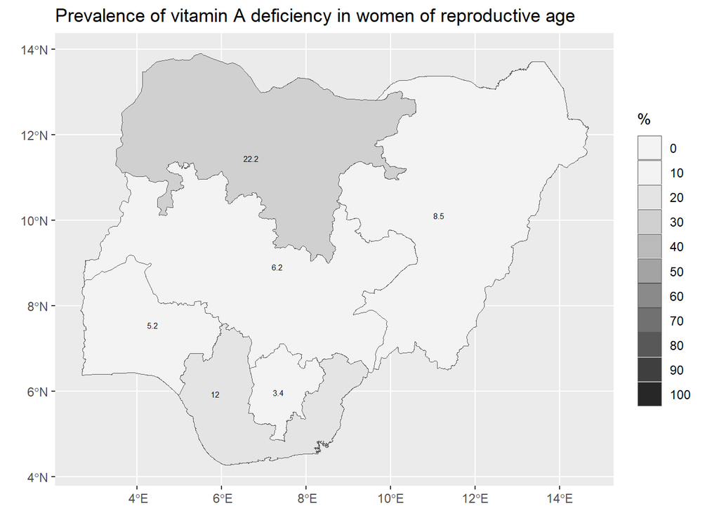

```r
ggplot(vect_gpz_geo_NFCMS) +
  geom_spatvector(aes(fill = WRA_def_vit_A_pc_246)) +
  geom_spatvector_text(aes(label = WRA_def_vit_A_pc_246), size = 2) +
  scale_fill_stepsn(
    n.breaks = 10,
    limits = c(0, 100),
    colours = hcl.colors(palette = "Grays", 10, rev = T),
    guide = "legend",
    na.value = "pink",
    labels = scales::comma
  ) +
  labs(title = "Prevalence of vitamin A deficiency in women of reproductive age", fill = " %") +
  theme(
    plot.title = element_markdown(),
    legend.title = element_markdown(),
    axis.title = element_blank()
  )
```

The highest values for vitamin A deficiency among women are in North West zone with 22.2%. These values are almost double the next highest value in South South. The lowest values are in South East with 3.4% of women with a deficiency.

### Vitamin A deficiency in children (NFCMS, 2021)

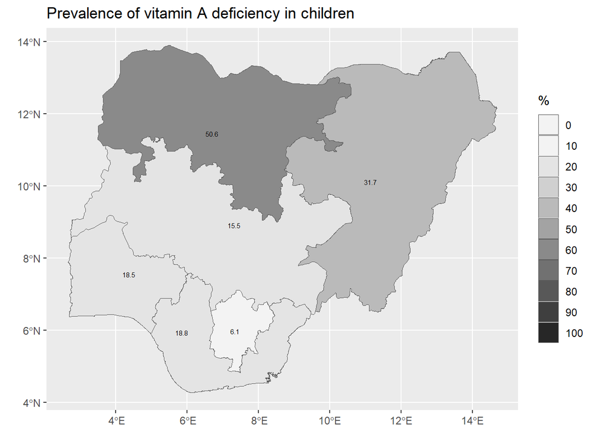

```r
ggplot(vect_gpz_geo_NFCMS) +
  geom_spatvector(aes(fill = CH_def_vit_A_pc_236)) +
  geom_spatvector_text(aes(label = CH_def_vit_A_pc_236), size = 2) +
  scale_fill_stepsn(
    n.breaks = 10,
    limits = c(0, 100),
    colours = hcl.colors(palette = "Grays", 10, rev = T),
    guide = "legend",
    na.value = "pink",
    labels = scales::comma
  ) +
  labs(title = "Prevalence of vitamin A deficiency in children", fill = " %") +
  theme(
    plot.title = element_markdown(),
    legend.title = element_markdown(),
    axis.title = element_blank()
  )
```

The pattern of vitamin A deficiency among children is similar, with the highest value again in North West zone with 50.6%. These values are 20% greater than in North East - the zone with next highest value. The lowest values were again in South East with 6.1% of children with a vitamin A deficiency.

### Age standardised DALYs Vitamin A Deficiency (IHME, 2023)

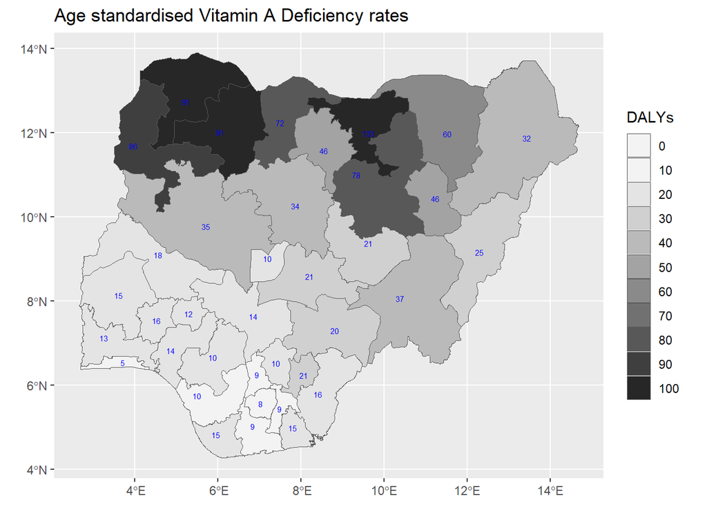

```r
ggplot(tidyterra::filter(vect_state_geo_IHME, cause_name == "Vitamin A deficiency")) +
  geom_spatvector(aes(fill = val)) +
  geom_spatvector_text(aes(label = round(val)), colour = "blue", size = 2) +
  scale_fill_stepsn(
    n.breaks = 10,
    limits = c(0, 100),
    colours = hcl.colors(palette = "Grays", 10, rev = T),
    guide = "legend",
    na.value = "pink",
    labels = scales::comma
  ) +
  labs(title = "Age standardised Vitamin A Deficiency rates", fill = "DALYs") +
  theme(
    plot.title = element_markdown(),
    legend.title = element_markdown(),
    axis.title = element_blank()
  )
```

The GBD estimates include Vitamin A deficiency as a risk/outcome category and DALYs attributable to VAD, with subnational estimates for Nigeria.

There is also an important methodological point: GBD’s VAD DALYs are connected to the health consequences attributed to VAD, rather than simply being a transformation of serum-retinol prevalence. For example, GBD estimates for Nigeria included VAD-related DALYs alongside the VAD prevalence and attributable fractions for measles and diarrhoeal disease.

There are large differences in the country, with the highest values in the North West of Nigeria. In contrast the burden of Vitamin A deficiency is very low in the South South and South East zones.

## Iron deficiency

### Iron deficiency in women of reproductive age (NFCMS, 2021)

Iron deficiency is defined as serum ferritin concentration <15 µg/L corrected for inflammation.

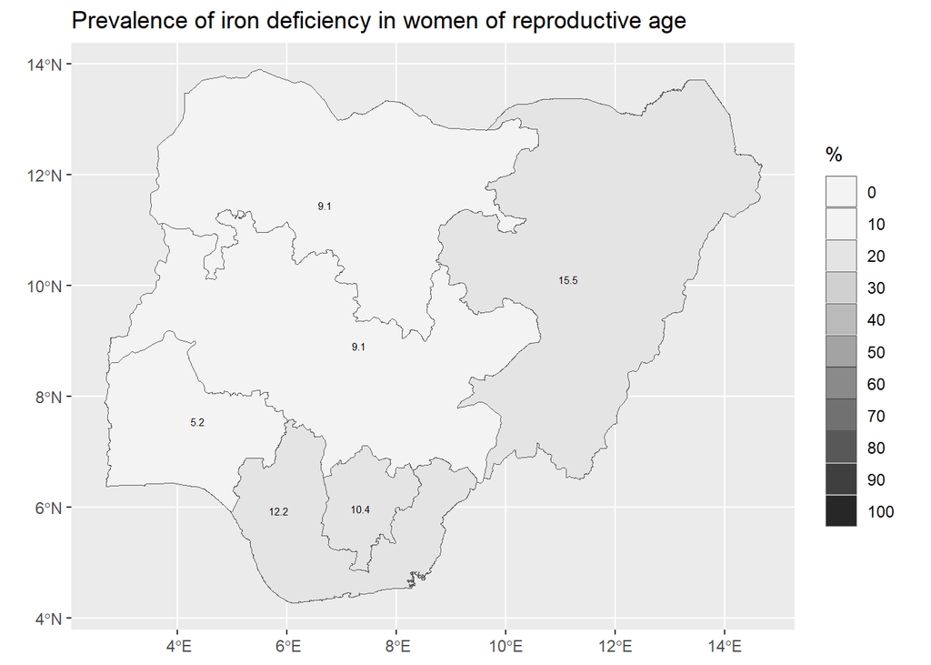

```r
ggplot(vect_gpz_geo_NFCMS) +
  geom_spatvector(aes(fill = WRA_def_iron_pc_245)) +
  geom_spatvector_text(aes(label = WRA_def_iron_pc_245), size = 2) +
  scale_fill_stepsn(
    n.breaks = 10,
    limits = c(0, 100),
    colours = hcl.colors(palette = "Grays", 10, rev = T),
    guide = "legend",
    na.value = "pink",
    labels = scales::comma
  ) +
  labs(title = "Prevalence of iron deficiency in women of reproductive age", fill = "%") +
  theme(
    plot.title = element_markdown(),
    legend.title = element_markdown(),
    axis.title = element_blank()
  )
```

Iron deficiency in women of reproductive age is highest in North East geopolitical zone, followed by South South and South East - all three had values higher than 10%. The zone with lowest value was South West.

### Age standardised DALYs Dietary iron Deficiency (IHME, 2023)

Dietary iron deficiency is a measure that seeks to isolate inadequate nutritional intake from other clinical causes of iron deficiency (like blood loss or parasites).

**NoteCalculating the dietary iron deficiency**

The IHME framework relies on a specialised, multi-step statistical workflow called the GBD Anaemia Causal Attribution framework to calculate dietary iron deficiency (Safiri et al. 2024).

#### Step 1: Modeling Total Anaemia Prevalence

Before estimating the dietary deficiency itself, IHME models the total envelope of anaemia across the globe (Young et al. 2023).

- Data Input: IHME extracts individual-level haemoglobin concentration data from major surveys (such as Demographic and Health Surveys) and international databases like the WHO Micronutrient Database.
- ST-GPR Modeling: They run a statistical engine called Spatiotemporal Gaussian Process Regression (ST-GPR). This mathematical model blends sparse local data with predictive covariates (like the Socio-demographic Index, or SDI) to estimate mean haemoglobin distribution profiles across different age, sex, geography, and time cohorts (Young et al. 2023).
- Severity Thresholds: They map these curves against clinical cutoffs to divide the population into categories: mild, moderate, or severe anaemia (Safiri et al. 2024).

#### Step 2: The Counterfactual and Residual Attribution

The core mathematical distinction of IHME’s calculation is that it treats dietary iron deficiency as a residual cause (Young et al. 2023; Safiri et al. 2024).
$${Dietary\ Iron\ Deficiency\ Burden}=\text{Total\ Anemia\ Envelope}-\sum (\text{Explicitly\ Attributed\ Causes})$$

- Explicit Cause Modelling: The model first subtracts the exact proportion of anaemia cases linked directly to specific conditions modelled within the Global Burden of Disease (GBD) framework. These explicit causes include
  - Infectious diseases (e.g., malaria, HIV/AIDS)
  - Neglected tropical diseases (e.g., hookworm, schistosomiasis)
  - Haemoglobinopathies (e.g., sickle cell disorders, thalassemias)
  - Chronic conditions (e.g., chronic kidney disease, endocrine disorders)
- The “Residual” Mathematics: Any remaining anaemia cases that cannot be mathematically explained by these specific infections or genetic traits are automatically distributed into the residual pool. Under this framework, dietary iron deficiency is designated as the primary bucket for this remaining health gap (Safiri et al. 2024).

#### Step 3: Quantifying the Health Loss (YLDs and DALYs)

Once the proportion of anaemia attributed exclusively to dietary iron deficiency is isolated, IHME converts it into standard health metrics:

1. Calculate YLDs (Years Lived with Disability):

$${YLD}=\text{Prevalence}\times \text{Disability\ Weight\ (DW)}$$
The model uses distinct disability weights evaluated by global panels to reflect the severity of cognitive and physical impairment:

1. Mild Anaemia DW: 0.004
2. Moderate Anaemia DW: 0.052
3. Severe Anaemia DW: 0.149
2. Calculate DALYs (Disability-Adjusted Life Years): Because dietary iron deficiency rarely causes direct mortality on its own, its DALY total is heavily weighted by YLDs (Huang et al. 2025).

#### Important Methodological Discrepancy

Because IHME calculates dietary iron deficiency mathematically as a residual framework of anaemia, its final estimations often yield higher prevalence numbers than traditional localized nutrition surveys. Nutrition surveys typically measure objective biomarkers directly (like serum ferritin or soluble transferrin receptor levels), whereas the GBD model absorbs undefined structural anaemias directly into the dietary iron category (Young et al. 2023; Safiri et al. 2024).

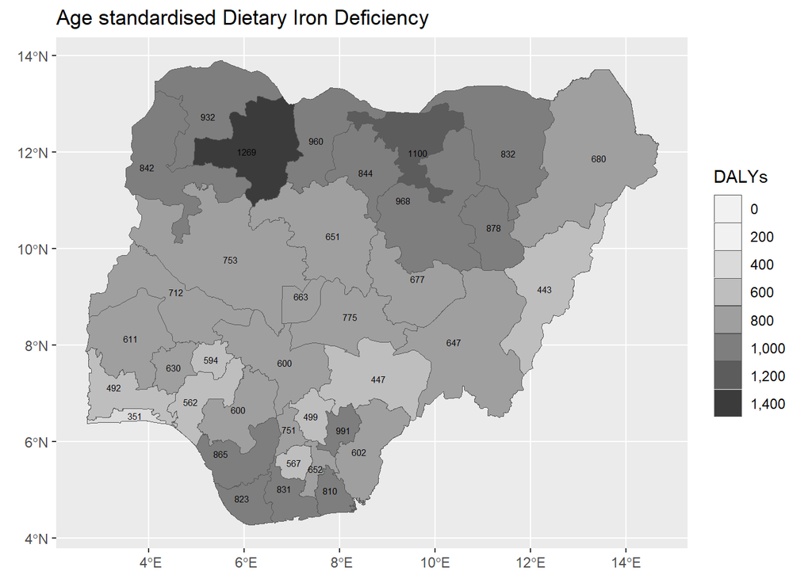

```r
ggplot(tidyterra::filter(vect_state_geo_IHME, cause_name == "Dietary iron deficiency")) +
  geom_spatvector(aes(fill = val)) +
  geom_spatvector_text(aes(label = round(val)), size = 2) +
  scale_fill_stepsn(
    n.breaks = 10,
    limits = c(0, 1500),
    colours = hcl.colors(palette = "Grays", 10, rev = T),
    guide = "legend",
    na.value = "pink",
    labels = scales::comma
  ) +
  labs(title = "Age standardised Dietary Iron Deficiency", fill = "DALYs") +
  theme(
    plot.title = element_markdown(),
    legend.title = element_markdown(),
    axis.title = element_blank()
  )
```

### Anaemia in women of reproductive age (NFCMS, 2021)

Iron deficiency anaemia defined as serum ferritin concentration <15 µg/L, adjusted for inflammation and adjusted haemoglobin <12 g/dL Estimates calculated using weights that account for survey design and non-response.

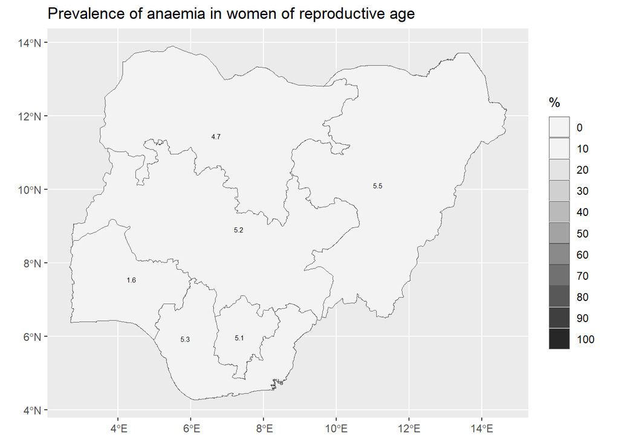

```r
ggplot(vect_gpz_geo_NFCMS) +
  geom_spatvector(aes(fill = WRA_def_anaemia_pc_245)) +
  geom_spatvector_text(aes(label = WRA_def_anaemia_pc_245), size = 2) +
  scale_fill_stepsn(
    n.breaks = 10,
    limits = c(0, 100),
    colours = hcl.colors(palette = "Grays", 10, rev = T),
    guide = "legend",
    na.value = "pink",
    labels = scales::comma
  ) +
  labs(title = "Prevalence of anaemia in women of reproductive age", fill = "%") +
  theme(
    plot.title = element_markdown(),
    legend.title = element_markdown(),
    axis.title = element_blank()
  )
```

The variation among zones of iron deficiency anaemia was small, varying between 4.7% and 5.5%, except in South West where the percentage of anaemic women was only 1.6%. The North East zone once again had the highest rate.

### Anaemia in women of reproductive age (NDHS, 2023-24)

The Nigeria Demographic and Health Survey of 2023-24 gives data for four levels of anaemia: (1) Any; (2) Mild; (3) Moderate, and; (4) Severe anaemia.

**Any anaemia** is when haemoglobin level <12.0 g/dl

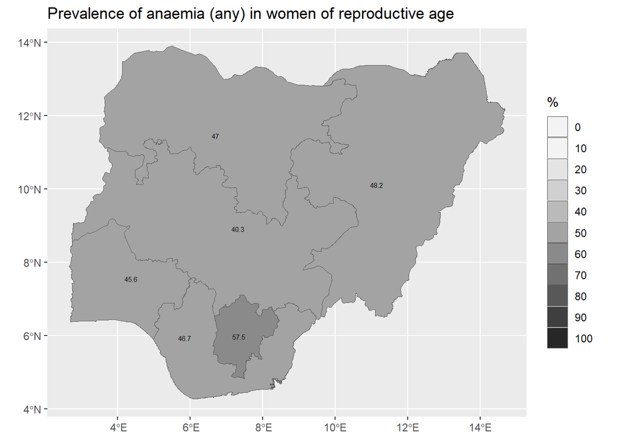

```r
ggplot(vect_zone_gpz_NDHS) +
  geom_spatvector(aes(fill = WRA_anaemia_any)) +
  geom_spatvector_text(aes(label = WRA_anaemia_any), size = 2) +
  scale_fill_stepsn(
    n.breaks = 10,
    limits = c(0, 100),
    colours = hcl.colors(palette = "Grays", 10, rev = T),
    guide = "legend",
    na.value = "pink",
    labels = scales::comma
  ) +
  labs(title = "Prevalence of anaemia (any) in women of reproductive age", fill = "%") +
  theme(
    plot.title = element_markdown(),
    legend.title = element_markdown(),
    axis.title = element_blank()
  )
```

The zone with the highest percentage of women with anaemia was South East, with over 50% of women. The other zones all had values between 40% and 50%. The zone with the lowest levels was North Central.

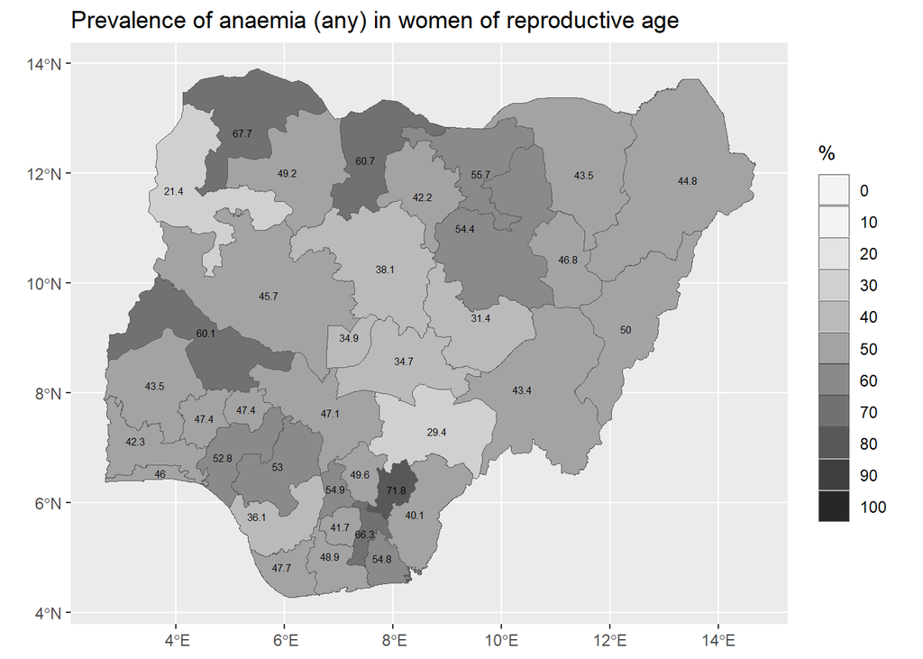

```r
ggplot(vect_state_geo_NDHS) +
  geom_spatvector(aes(fill = WRA_anaemia_any)) +
  geom_spatvector_text(aes(label = WRA_anaemia_any), size = 2) +
  scale_fill_stepsn(
    n.breaks = 10,
    limits = c(0, 100),
    colours = hcl.colors(palette = "Grays", 10, rev = T),
    guide = "legend",
    na.value = "pink",
    labels = scales::comma
  ) +
  labs(title = "Prevalence of anaemia (any) in women of reproductive age", fill = "%") +
  theme(
    plot.title = element_markdown(),
    legend.title = element_markdown(),
    axis.title = element_blank()
  )
```

The individual states show a more mixed pattern. The state with the highest value is Ebonyi with 71.8% of women anaemic. Other states in the same zone (South East) have lower values, such as Imo with 41.7%.

In North West zone there are instances of negative spatial auto-correlation where neighbouring states have very different values - a clear example is the difference between Sokoto (67.7%) and Kebbi (21.4%). States in South West zone, in contrast, have more similar values.

**Mild anaemia** when haemoglobin level 11.0–11.9 g/dl

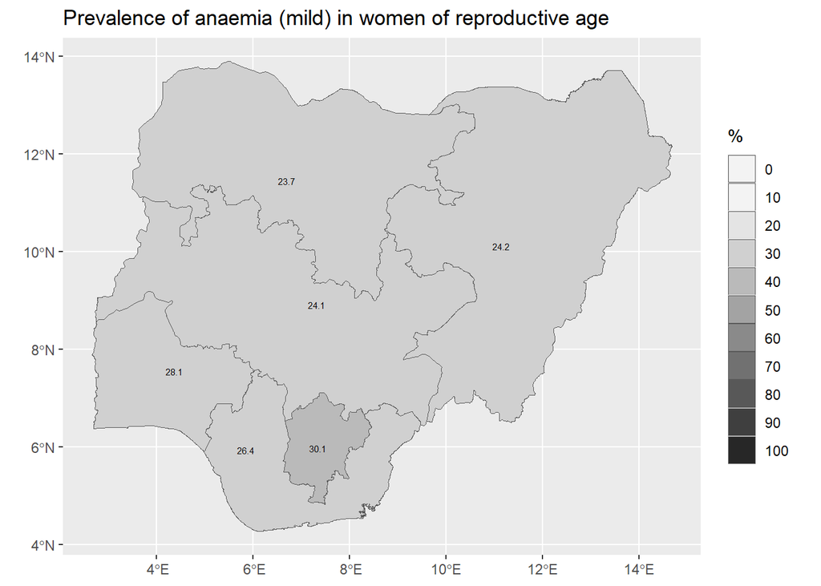

```r
ggplot(vect_zone_gpz_NDHS) +
  geom_spatvector(aes(fill = WRA_anaemia_mild)) +
  geom_spatvector_text(aes(label = WRA_anaemia_mild), size = 2) +
  scale_fill_stepsn(
    n.breaks = 10,
    limits = c(0, 100),
    colours = hcl.colors(palette = "Grays", 10, rev = T),
    guide = "legend",
    na.value = "pink",
    labels = scales::comma
  ) +
  labs(title = "Prevalence of anaemia (mild) in women of reproductive age", fill = "%") +
  theme(
    plot.title = element_markdown(),
    legend.title = element_markdown(),
    axis.title = element_blank()
  )
```

The zone with the highest percentage of women with mild anaemia was South East, with over 30% of women. The other zones all had values between 20% and 30%. The zone with the lowest levels was North West

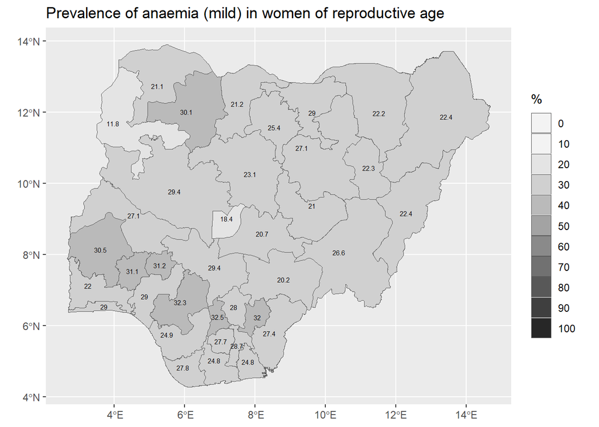

```r
ggplot(vect_state_geo_NDHS) +
  geom_spatvector(aes(fill = WRA_anaemia_mild)) +
  geom_spatvector_text(aes(label = WRA_anaemia_mild), size = 2) +
  scale_fill_stepsn(
    n.breaks = 10,
    limits = c(0, 100),
    colours = hcl.colors(palette = "Grays", 10, rev = T),
    guide = "legend",
    na.value = "pink",
    labels = scales::comma
  ) +
  labs(title = "Prevalence of anaemia (mild) in women of reproductive age", fill = "%") +
  theme(
    plot.title = element_markdown(),
    legend.title = element_markdown(),
    axis.title = element_blank()
  )
```

For mild anaemia Ebonyi is no longer the state with the highest values. There are numerous southern states with values around 30%. In the North East zone the values per state are very similar, whereas in North West there is again a big difference between Kebbi and its neighbouring states.

**Moderate anaemia** when haemoglobin level 8.0–10.9 g/dl

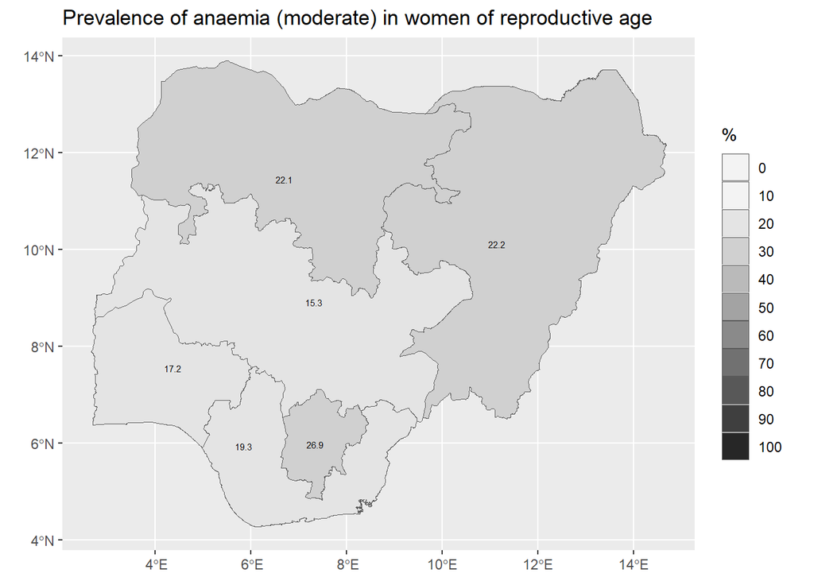

```r
ggplot(vect_zone_gpz_NDHS) +
  geom_spatvector(aes(fill = WRA_anaemia_mod)) +
  geom_spatvector_text(aes(label = WRA_anaemia_mod), size = 2) +
  scale_fill_stepsn(
    n.breaks = 10,
    limits = c(0, 100),
    colours = hcl.colors(palette = "Grays", 10, rev = T),
    guide = "legend",
    na.value = "pink",
    labels = scales::comma
  ) +
  labs(title = "Prevalence of anaemia (moderate) in women of reproductive age", fill = "%") +
  theme(
    plot.title = element_markdown(),
    legend.title = element_markdown(),
    axis.title = element_blank()
  )
```

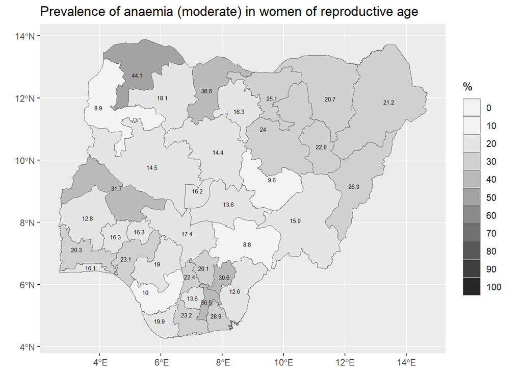

```r
ggplot(vect_state_geo_NDHS) +
  geom_spatvector(aes(fill = WRA_anaemia_mod)) +
  geom_spatvector_text(aes(label = WRA_anaemia_mod), size = 2) +
  scale_fill_stepsn(
    n.breaks = 10,
    limits = c(0, 100),
    colours = hcl.colors(palette = "Grays", 10, rev = T),
    guide = "legend",
    na.value = "pink",
    labels = scales::comma
  ) +
  labs(title = "Prevalence of anaemia (moderate) in women of reproductive age", fill = "%") +
  theme(
    plot.title = element_markdown(),
    legend.title = element_markdown(),
    axis.title = element_blank()
  )
```

The state with the highest value for moderate anaemia is Sokoto, with 44% of women - a higher value than for mild anaemia. A similar situation is encountered in Katsina, Adamawa, Abia, Ebonyi, and Akwa Ibom states.

**Severe anaemia** when haemoglobin level <8.0 g/dl

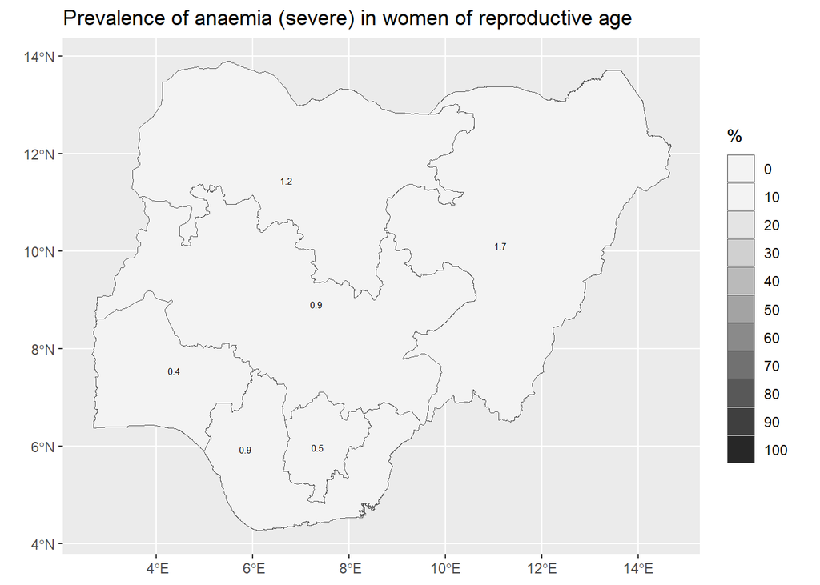

```r
ggplot(vect_zone_gpz_NDHS) +
  geom_spatvector(aes(fill = WRA_anaemia_sev)) +
  geom_spatvector_text(aes(label = WRA_anaemia_sev), size = 2) +
  scale_fill_stepsn(
    n.breaks = 10,
    limits = c(0, 100),
    colours = hcl.colors(palette = "Grays", 10, rev = T),
    guide = "legend",
    na.value = "pink",
    labels = scales::comma
  ) +
  labs(title = "Prevalence of anaemia (severe) in women of reproductive age", fill = "%") +
  theme(
    plot.title = element_markdown(),
    legend.title = element_markdown(),
    axis.title = element_blank()
  )
```

There was a different spatial pattern for severe anaemia. The zone with the highest percentage of women with severe anaemia was North East, 1.7% of women anaemic. The other zones varied between 0.4% and 1.2%. The zone with the lowest levels was South West.

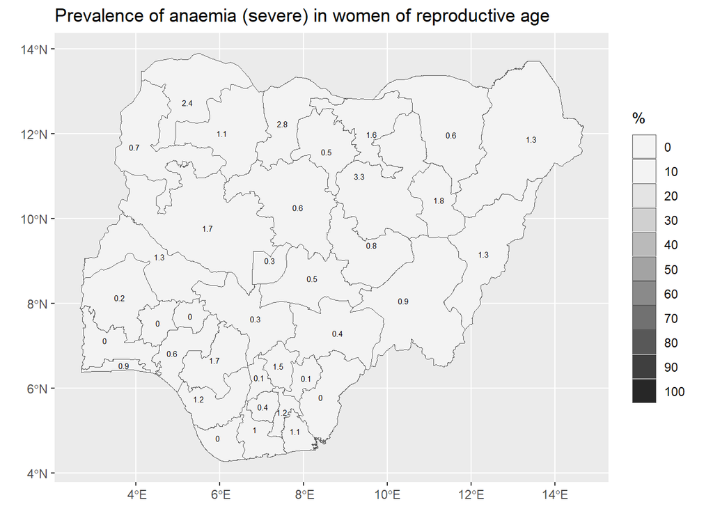

```r
ggplot(vect_state_geo_NDHS) +
  geom_spatvector(aes(fill = WRA_anaemia_sev)) +
  geom_spatvector_text(aes(label = WRA_anaemia_sev), size = 2) +
  scale_fill_stepsn(
    n.breaks = 10,
    limits = c(0, 100),
    colours = hcl.colors(palette = "Grays", 10, rev = T),
    guide = "legend",
    na.value = "pink",
    labels = scales::comma
  ) +
  labs(title = "Prevalence of anaemia (severe) in women of reproductive age", fill = "%") +
  theme(
    plot.title = element_markdown(),
    legend.title = element_markdown(),
    axis.title = element_blank()
  )
```

Levels of severe anaemia show less obvious differences within geopolitical zones, except in North East where Bauchi has the highest value for any state with 3.3% but neighbouring Yobe has a value of 0.6%. South West zone has consistently low vales for severe anaemia.

### Compare sources

The only micro nutrient for which there are data in different sources is for iron. However, there are some differences in the indicators used for iron deficiency anaemia in the two sources.

The NDHS has a finer spatial resolution, and the data were collected more recently. The only issue would be to decide which of the four anaemia indicators to use.

### Iron deficiency in children between 6 and 59 months (NFCMS, 2021)

Iron deficiency is defined as serum ferritin concentration <15 µg/L corrected for inflammation.

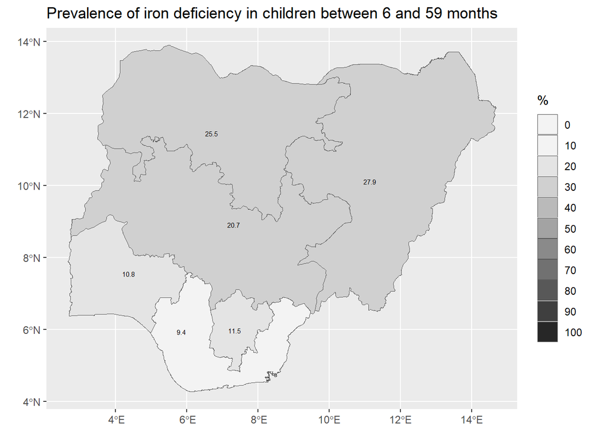

```r
ggplot(vect_gpz_geo_NFCMS) +
  geom_spatvector(aes(fill = CH_def_iron_pc_235)) +
  geom_spatvector_text(aes(label = CH_def_iron_pc_235), size = 2) +
  scale_fill_stepsn(
    n.breaks = 10,
    limits = c(0, 100),
    colours = hcl.colors(palette = "Grays", 10, rev = T),
    guide = "legend",
    na.value = "pink",
    labels = scales::comma
  ) +
  labs(title = "Prevalence of iron deficiency in children between 6 and 59 months", fill = "%") +
  theme(
    plot.title = element_markdown(),
    legend.title = element_markdown(),
    axis.title = element_blank()
  )
```

Iron deficiency among children in 2021 was far higher in the northern geopolitical zones than in the south. North East zone had the highest values while South South had the lowest. This was a differing pattern to that for women of reproductive age.

### Anaemia in children between 6 and 59 months (NFCMS, 2021)

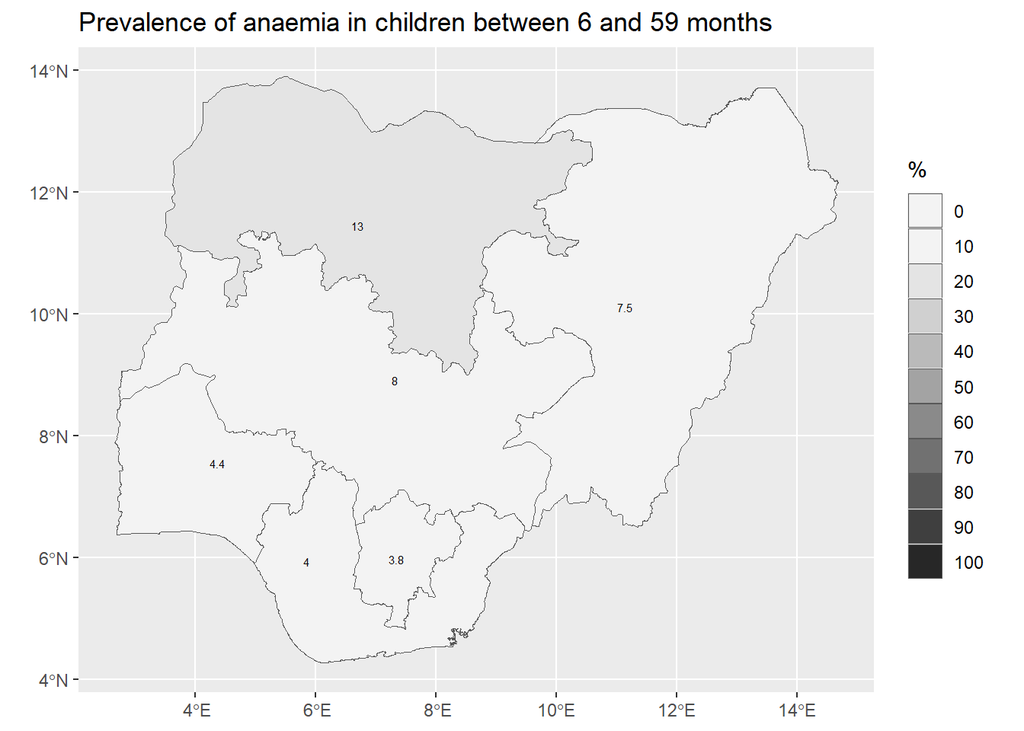

```r
ggplot(vect_gpz_geo_NFCMS) +
  geom_spatvector(aes(fill = CH_def_anaemia_pc_235)) +
  geom_spatvector_text(aes(label = CH_def_anaemia_pc_235), size = 2) +
  scale_fill_stepsn(
    n.breaks = 10,
    limits = c(0, 100),
    colours = hcl.colors(palette = "Grays", 10, rev = T),
    guide = "legend",
    na.value = "pink",
    labels = scales::comma
  ) +
  labs(title = "Prevalence of anaemia in children between 6 and 59 months", fill = "%") +
  theme(
    plot.title = element_markdown(),
    legend.title = element_markdown(),
    axis.title = element_blank()
  )
```

Anaemia among young children is highest in North West zone, with far lower figures in the southern zones. The pattern is slightly different to iron deficiency with bigger differences among the northern states

### Anaemia in children between 6 and 59 months (NDHS, 2023-24)

The Nigeria Demographic and Health Survey of 2023-24 gives data for four levels of anaemia: (1) Any; (2) Mild; (3) Moderate, and; (4) Severe anaemia.

**Any anaemia** is when haemoglobin level <12.0 g/dl

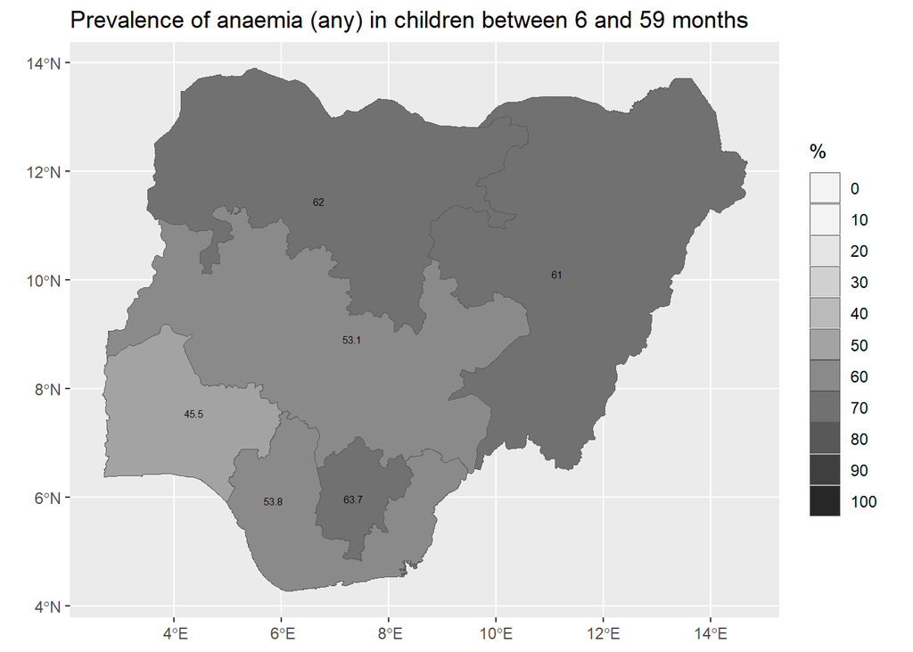

```r
ggplot(vect_zone_gpz_NDHS) +
  geom_spatvector(aes(fill = CH_anaemia_any)) +
  geom_spatvector_text(aes(label = CH_anaemia_any), size = 2) +
  scale_fill_stepsn(
    n.breaks = 10,
    limits = c(0, 100),
    colours = hcl.colors(palette = "Grays", 10, rev = T),
    guide = "legend",
    na.value = "pink",
    labels = scales::comma
  ) +
  labs(title = "Prevalence of anaemia (any) in children between 6 and 59 months", fill = "%") +
  theme(
    plot.title = element_markdown(),
    legend.title = element_markdown(),
    axis.title = element_blank()
  )
```

Levels of child anaemia are high throughout Nigeria with five out of six zones showing rates above 50%. The zone with the highest percentage is South East with 63.7%, while the lowest is in South West with 45.5%.

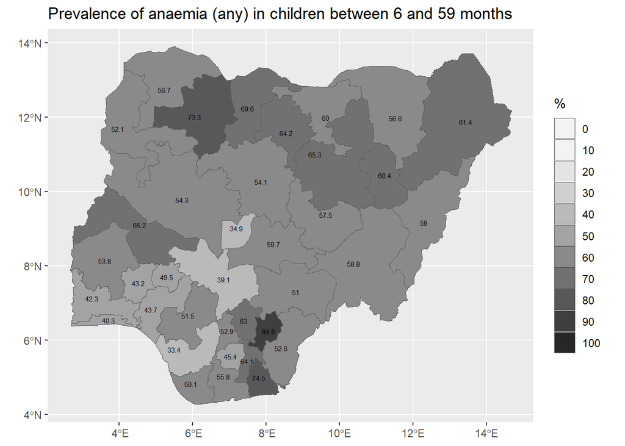

```r
ggplot(vect_state_geo_NDHS) +
  geom_spatvector(aes(fill = CH_anaemia_any)) +
  geom_spatvector_text(aes(label = CH_anaemia_any), size = 2) +
  scale_fill_stepsn(
    n.breaks = 10,
    limits = c(0, 100),
    colours = hcl.colors(palette = "Grays", 10, rev = T),
    guide = "legend",
    na.value = "pink",
    labels = scales::comma
  ) +
  labs(title = "Prevalence of anaemia (any) in children between 6 and 59 months", fill = "%") +
  theme(
    plot.title = element_markdown(),
    legend.title = element_markdown(),
    axis.title = element_blank()
  )
```

The individual states show a more mixed pattern. The state with the highest value is Ebonyi with 84.8% of children anaemic, the next highest value is 74.5% in Akwa Ibom state in South South zone.

The state with the lowest value is Delta state with 33.4%.

**Mild anaemia** when haemoglobin level 11.0–11.9 g/dl

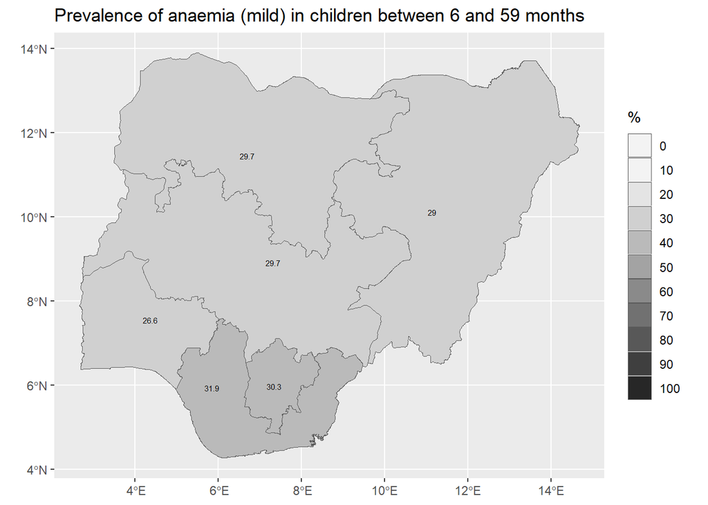

```r
ggplot(vect_zone_gpz_NDHS) +
  geom_spatvector(aes(fill = CH_anaemia_mild)) +
  geom_spatvector_text(aes(label = CH_anaemia_mild), size = 2) +
  scale_fill_stepsn(
    n.breaks = 10,
    limits = c(0, 100),
    colours = hcl.colors(palette = "Grays", 10, rev = T),
    guide = "legend",
    na.value = "pink",
    labels = scales::comma
  ) +
  labs(title = "Prevalence of anaemia (mild) in children between 6 and 59 months", fill = "%") +
  theme(
    plot.title = element_markdown(),
    legend.title = element_markdown(),
    axis.title = element_blank()
  )
```

The zone with the highest percentage of women with mild anaemia was South South, with over 30% of children However all zones had values between 26% and 32%. The zone with the lowest levels was South West.

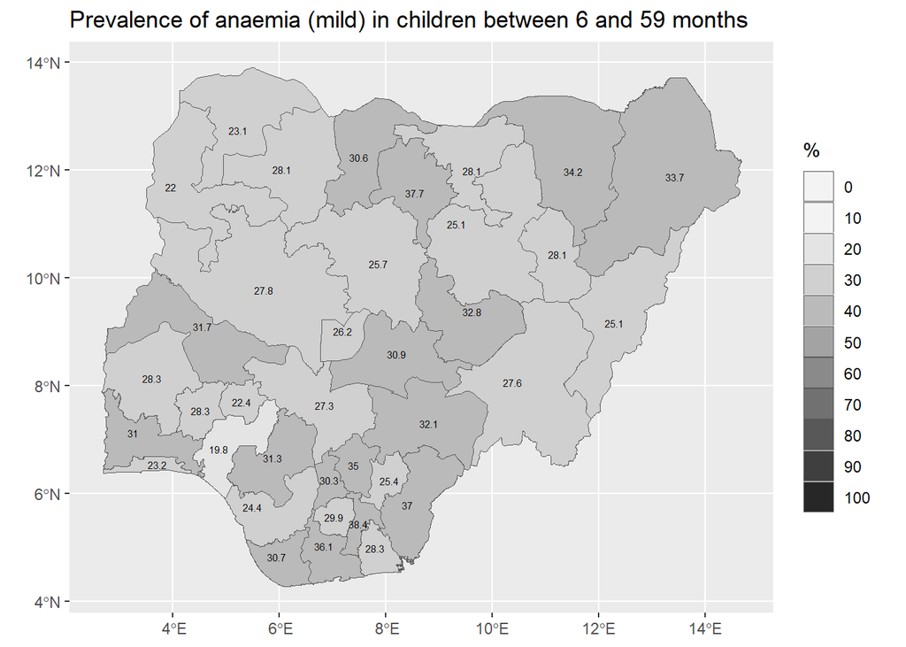

```r
ggplot(vect_state_geo_NDHS) +
  geom_spatvector(aes(fill = CH_anaemia_mild)) +
  geom_spatvector_text(aes(label = CH_anaemia_mild), size = 2) +
  scale_fill_stepsn(
    n.breaks = 10,
    limits = c(0, 100),
    colours = hcl.colors(palette = "Grays", 10, rev = T),
    guide = "legend",
    na.value = "pink",
    labels = scales::comma
  ) +
  labs(title = "Prevalence of anaemia (mild) in children between 6 and 59 months", fill = "%") +
  theme(
    plot.title = element_markdown(),
    legend.title = element_markdown(),
    axis.title = element_blank()
  )
```

For mild anaemia in children the differences among states are not great, with the highest at 38.4% in Abia (South East) and the lowest at 19.8% in Ondo (South West).

**Moderate anaemia** when haemoglobin level 8.0–10.9 g/dl

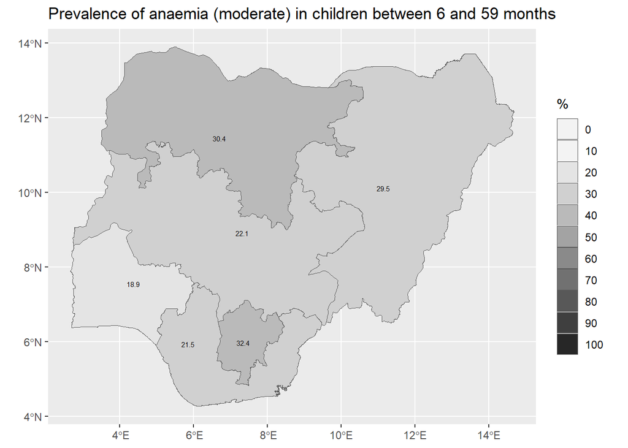

```r
ggplot(vect_zone_gpz_NDHS) +
  geom_spatvector(aes(fill = CH_anaemia_mod)) +
  geom_spatvector_text(aes(label = CH_anaemia_mod), size = 2) +
  scale_fill_stepsn(
    n.breaks = 10,
    limits = c(0, 100),
    colours = hcl.colors(palette = "Grays", 10, rev = T),
    guide = "legend",
    na.value = "pink",
    labels = scales::comma
  ) +
  labs(title = "Prevalence of anaemia (moderate) in children between 6 and 59 months", fill = "%") +
  theme(
    plot.title = element_markdown(),
    legend.title = element_markdown(),
    axis.title = element_blank()
  )
```

The zone with the highest percentage of children with moderate anaemia was again South East, with over 32% of children The other zones varied between 19% and 31% - a bigger range than for mild anaemia. The zone with the lowest levels was South West.

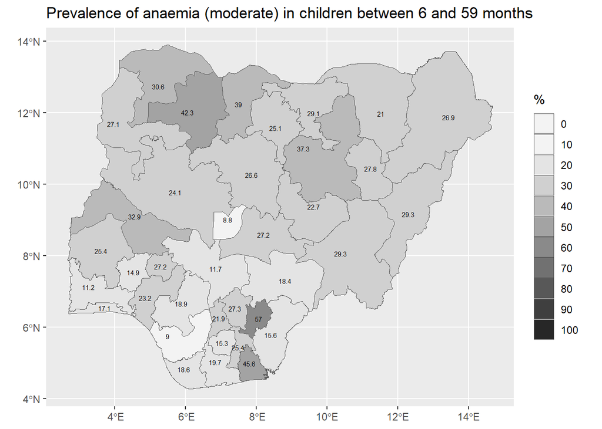

```r
ggplot(vect_state_geo_NDHS) +
  geom_spatvector(aes(fill = CH_anaemia_mod)) +
  geom_spatvector_text(aes(label = CH_anaemia_mod), size = 2) +
  scale_fill_stepsn(
    n.breaks = 10,
    limits = c(0, 100),
    colours = hcl.colors(palette = "Grays", 10, rev = T),
    guide = "legend",
    na.value = "pink",
    labels = scales::comma
  ) +
  labs(title = "Prevalence of anaemia (moderate) in children between 6 and 59 months", fill = "%") +
  theme(
    plot.title = element_markdown(),
    legend.title = element_markdown(),
    axis.title = element_blank()
  )
```

There are some very big differences in the levels of moderate anaemia among the states - with a low of 9% in the Federal Capital Territory and Delta states, while Ebonyi, Akwa Ibom and Zamfara had levels above 40%.

These are patterns which were masked in the zone map.

**Severe anaemia** when haemoglobin level <8.0 g/dl

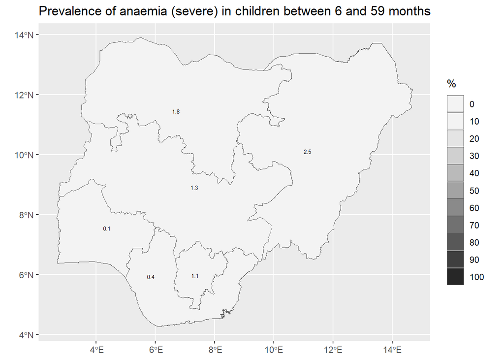

```r
ggplot(vect_zone_gpz_NDHS) +
  geom_spatvector(aes(fill = CH_anaemia_sev)) +
  geom_spatvector_text(aes(label = CH_anaemia_sev), size = 2) +
  scale_fill_stepsn(
    n.breaks = 10,
    limits = c(0, 100),
    colours = hcl.colors(palette = "Grays", 10, rev = T),
    guide = "legend",
    na.value = "pink",
    labels = scales::comma
  ) +
  labs(title = "Prevalence of anaemia (severe) in children between 6 and 59 months", fill = "%") +
  theme(
    plot.title = element_markdown(),
    legend.title = element_markdown(),
    axis.title = element_blank()
  )
```

There was a different spatial pattern for severe anaemia. The zone with the highest percentage of children with severe anaemia was North East, 2.5% of children anaemic. The other zones varied between 0.1% and 1.8%. The zone with the lowest levels was South West. This showed a similar pattern to the values for women of reproductive age.

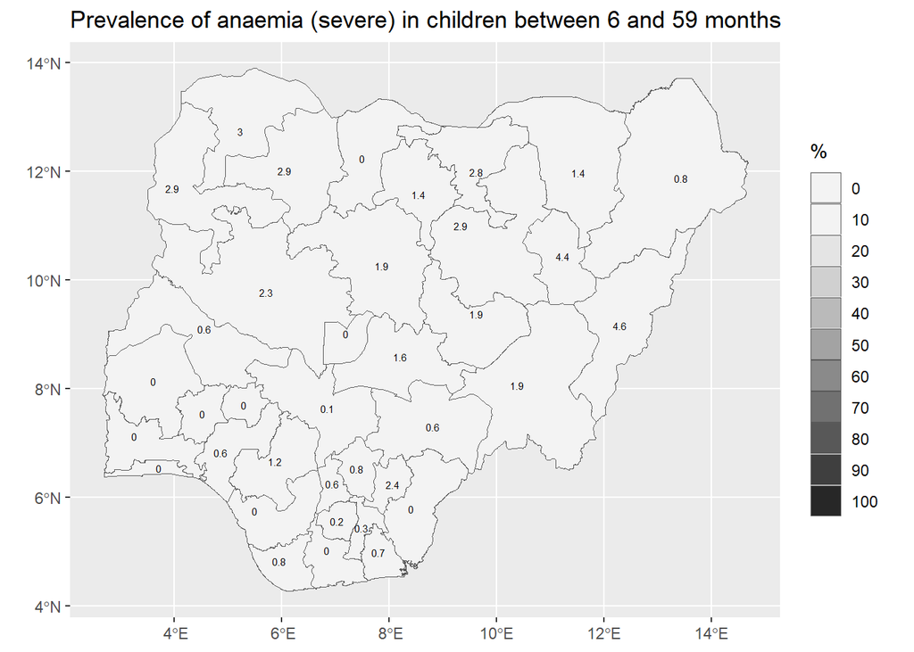

```r
ggplot(vect_state_geo_NDHS) +
  geom_spatvector(aes(fill = CH_anaemia_sev)) +
  geom_spatvector_text(aes(label = CH_anaemia_sev), size = 2) +
  scale_fill_stepsn(
    n.breaks = 10,
    limits = c(0, 100),
    colours = hcl.colors(palette = "Grays", 10, rev = T),
    guide = "legend",
    na.value = "pink",
    labels = scales::comma
  ) +
  labs(title = "Prevalence of anaemia (severe) in children between 6 and 59 months", fill = "%") +
  theme(
    plot.title = element_markdown(),
    legend.title = element_markdown(),
    axis.title = element_blank()
  )
```

Levels of severe anaemia show less obvious differences within geopolitical zones, except in North East where Adamawa has the highest value for any state with 4.6% but neighbouring Borno has a value of 0.8%. North West zone also has large differences among states, while states in South West zone have consistently low vales for severe anaemia.

**Combined Moderate and Severe anaemia** when haemoglobin level <11.0 g/dl

The global Biofortification Priority Index (BPI) (Asare-Marfo et al. 2013) uses an indicator of the proportion of preschool-age children with Hb < 110 g/l. This value is equivalent to the definitions of moderate and severe anaemia in children in the NDHS report.

As a result, the two percentages are added together. Due to the low levels of severe anaemia in children the map of combined anaemia is similar to that of moderate anaemia, with high values in Ebonyi, Akwa Ibom and Zamfara.

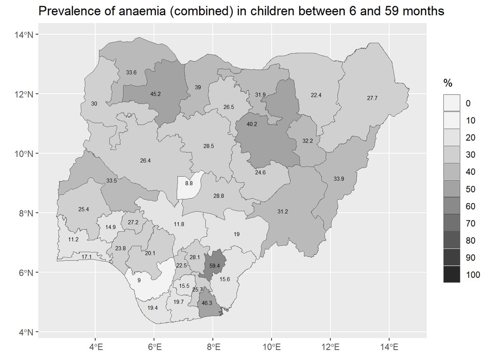

```r
vect_state_geo_NDHS$CH_anaemia_comb <- (vect_state_geo_NDHS$CH_anaemia_mod + vect_state_geo_NDHS$CH_anaemia_sev)


ggplot(vect_state_geo_NDHS) +
  geom_spatvector(aes(fill = CH_anaemia_comb)) +
  geom_spatvector_text(aes(label = CH_anaemia_comb), size = 2) +
  scale_fill_stepsn(
    n.breaks = 10,
    limits = c(0, 100),
    colours = hcl.colors(palette = "Grays", 10, rev = T),
    guide = "legend",
    na.value = "pink",
    labels = scales::comma
  ) +
  labs(title = "Prevalence of anaemia (combined) in children between 6 and 59 months", fill = "%") +
  theme(
    plot.title = element_markdown(),
    legend.title = element_markdown(),
    axis.title = element_blank()
  )
```

### Compare sources

The only micro nutrient for which there are data in different sources is for iron. However, there are some differences in the indicators used for iron deficiency anaemia in the two sources.

The NDHS has a finer spatial resolution, and the data were collected more recently. The four anaemia indicators can be mapped independently, or combined to be consistent with the global BPI.

## Zinc deficiency

### Zinc deficiency in women of reproductive age (NFCMS, 2021)

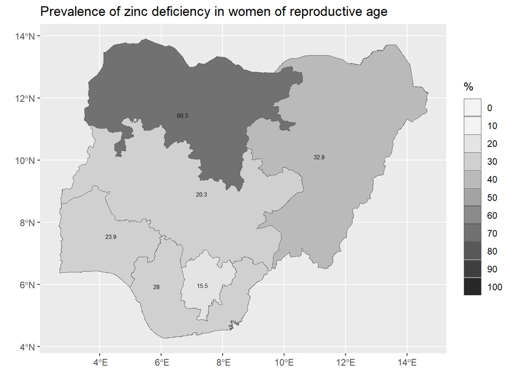

```r
ggplot(vect_gpz_geo_NFCMS) +
  geom_spatvector(aes(fill = WRA_def_zinc_pc_252)) +
  geom_spatvector_text(aes(label = WRA_def_zinc_pc_252), size = 2) +
  scale_fill_stepsn(
    n.breaks = 10,
    limits = c(0, 100),
    colours = hcl.colors(palette = "Grays", 10, rev = T),
    guide = "legend",
    na.value = "pink",
    labels = scales::comma
  ) +
  labs(title = "Prevalence of zinc deficiency in women of reproductive age", fill = "%") +
  theme(
    plot.title = element_markdown(),
    legend.title = element_markdown(),
    axis.title = element_blank()
  )
```

There are large differences in the percentage of women of reproductive age with zinc deficiency among geopolitical zones in Nigeria. The zone with the lowest values is South East, with 15.5%, whereas in North West over 60% of women are deficient in zinc.

### Zinc deficiency in children (NFCMS, 2021)

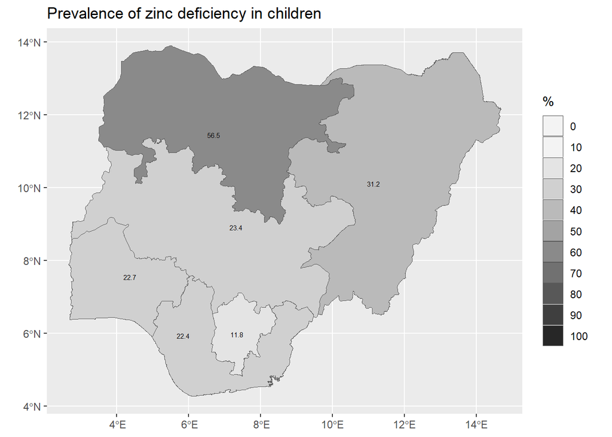

```r
ggplot(vect_gpz_geo_NFCMS) +
  geom_spatvector(aes(fill = CH_def_zinc_pc_238)) +
  geom_spatvector_text(aes(label = CH_def_zinc_pc_238), size = 2) +
  scale_fill_stepsn(
    n.breaks = 10,
    limits = c(0, 100),
    colours = hcl.colors(palette = "Grays", 10, rev = T),
    guide = "legend",
    na.value = "pink",
    labels = scales::comma
  ) +
  labs(title = "Prevalence of zinc deficiency in children", fill = "%") +
  theme(
    plot.title = element_markdown(),
    legend.title = element_markdown(),
    axis.title = element_blank()
  )
```

The patterns of zinc deficiency for children are almost exactly the same for children. The zone with the lowest values is again South East, with 11.8%, whereas in North West over 55% of young children are zinc deficient.

### Stunting in children

Stunting is an indicator of zinc deficiency in children. Data at subnational level in Nigeria are available from a number of sources:

| Source | Year | Geography | Type |
| --- | --- | --- | --- |
| NDHS | 2024 | 36 states + FCT | Survey |
| NFCMS | 2021 | Zones | Survey |
| NDHS/DHS | 2018 | 36 states + FCT | Survey |
| DHS | 2018 | States + LGAs | spatial modelling |

The most recent data on stunting are from the 2023-2024 NDHS, and the spatial level is the state which is preferable to the 2021 NFCMS.

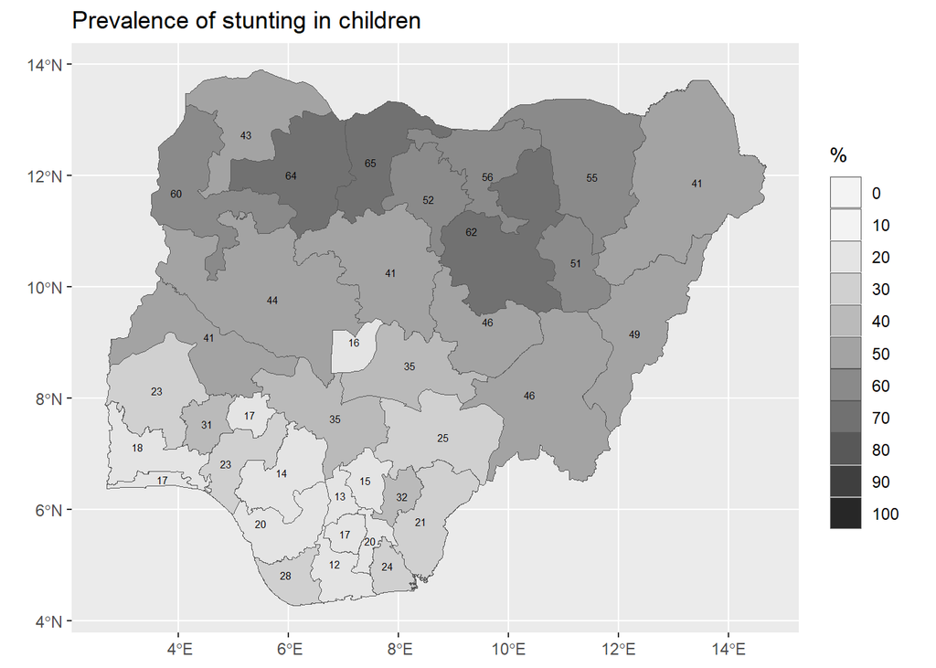

```r
ggplot(vect_state_geo_NDHS_stunting) +
  geom_spatvector(aes(fill = stunting_ndhs2024_pct)) +
  geom_spatvector_text(aes(label = stunting_ndhs2024_pct), size = 2) +
  scale_fill_stepsn(
    n.breaks = 10,
    limits = c(0, 100),
    colours = hcl.colors(palette = "Grays", 10, rev = T),
    guide = "legend",
    na.value = "pink",
    labels = scales::comma
  ) +
  labs(title = "Prevalence of stunting in children", fill = "%") +
  theme(
    plot.title = element_markdown(),
    legend.title = element_markdown(),
    axis.title = element_blank()
  )
```

The spatial patterns of stunting are somewhat similar to those of zinc deficiency in children, with higher incidences in the states of the North West, and also high levels in the states of North East. For zinc deficiency the rates in North Central are more or less equivalent to those in South South or South West. However, for stunting this pattern is not repeated apart from the Federal Capital Territory. The states in South East zone have the lowest rates of stunting - consistent with the zinc deficiency in children from 2021.

## References

Asare-Marfo, Dorene, Ekin Birol, Carolina Gonzalez, et al. 2013. *Prioritizing Countries for Biofortifcation Interventions Using Country-Level Data*. Vol. 11. HarvestPlus.

Federal Government of Nigeria (FGoN), and International Institute of Tropical Agriculture (IITA). 2024. *National Food Consumption and Micronutrient Survey 2021. Final Report.* FGoN and IITA.

Federal Ministry of Health and Social Welfare of Nigeria (FMoHSW), National Population Commission (NPC) [Nigeria], and ICF. 2025. *Nigeria Demographic and Health Survey 2024*. FMoHSW; NPC; ICF.

Huang, S., H. Li, L. Zhang, H. Chen, and C. Gao. 2025. “Global Burden of Diseases Associated With Iron Deficiency: GBD 2021.” *Int J Vitam Nutr Res* 95 (3): 31351. https://doi.org/10.31083/IJVNR31351.

Ishida, Sahoko, Mohammed Osman, Ziyao Cui, et al. 2026 (submitted). *Mapping Subnational Vulnerability to Inadequate Micronutrient Intake Using a Bayesian Small Area Estimation Framework*. 2026 (submitted).

Safiri, S., F. Amiri, N. Karamzad, M. J. M. Sullman, A. A. Kolahi, and M. Abdollahi. 2024. “Burden and Trends of Dietary Iron Deficiency in the Middle East and North Africa Region, 1990-2021.” *Front Nutr* 11: 1517478. https://doi.org/10.3389/fnut.2024.1517478.

Young, M. F., H. Luo, and P. S. Suchdev. 2023. “The Challenge of Defining the Global Burden of Iron Deficiency Anaemia.” *Lancet Haematol* 10 (9): e702–4. https://doi.org/10.1016/S2352-3026(23)00168-0.